# Lab 3

Sam Pell

September 09, 2022

# 1 Lab 3

## 1.1 Introduction

In this lab assignment, make sure you work in order of the code chunks, and **knit** after you complete each code chunk.

Consider the dataset `Wages1` from the `Ecdat` package.

```
##   exper    sex school     wage
## 1     9 female     13 6.315296
## 2    12 female     12 5.479770
## 3    11 female     11 3.642170
## 4     9 female     14 4.593337
## 5     8 female     14 2.418157
## 6     9 female     14 2.094058
```

This observational dataset records the years experienced, the years schooled, the sex, and the hourly wage for 3,294 workers in 1987. *A Guide to Modern Econometrics* by Marno Verbeek utilizes this data in a linear regression context. According to Marno Verbeek, this data is a subsample from the US National Longitudinal Study. The purpose of this tutorial is to practice the creative process in exploratory data analysis of asking questions and then investigating those questions using visuals and statistical summaries.

As a member of the birth class of 1997, I do not have any clue of what the workforce looked like in 1987. It is your job to apply your detective skills to the information hidden in this data. For future use, utilize the modified dataset`wage` according to the R code below:

```r
wage=as.tibble(Wages1) %>%
  rename(experience=exper) %>%
  arrange(school)
head(wage)
```

```
## # A tibble: 6 x 4
##   experience sex    school  wage
##        <int> <fct>   <int> <dbl>
## 1         18 male        3 5.52
## 2         15 male        4 3.56
## 3         18 male        4 9.10
## 4         10 female      5 0.603
## 5         11 male        5 3.80
## 6         14 male        5 7.50
```

## 1.2 : Questions About Measures of Center

### 1.2.1 :

Use a figure to find what is the most common number of years of experience found in the data (1 Points).

First, use `geom_bar()` to investigate the distribution of level of experience found in `wage`.

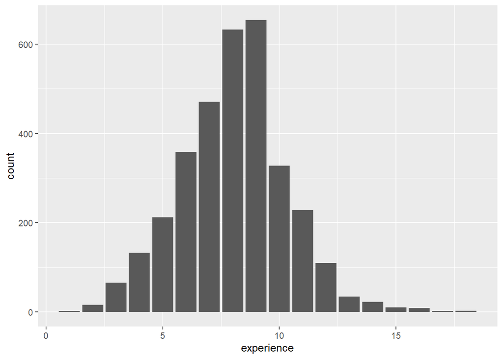

```r
ggplot(wage) +
  geom_bar(mapping = aes(experience))
```

### 1.2.2 : Nine years of experience is the most common value in the dataset.

Now let’s be a bit more precise. Define a variable, `experience` by subsetting the tibble `wage`, and find its mode. Unlike mean and median, mode does not have a built-in function [^1], so I have written one myself for you to use. This will return the most common experience level, but then I want you to use the `nrow` function coupled with a logical operator to count the number of observations having exactly this level of experience. (1.5 pts)

```r
# Create the function.
getmode <- function(v) {
   uniqv <- unique(v)
   uniqv[which.max(tabulate(match(v, uniqv)))]
}

#student input
experience<- wage[[1]]
MODE<-getmode(experience)
MODE
```

```
## [1] 9
```

```r
nrow(wage[wage$experience == MODE,])
```

```
## [1] 654
```

There are exactly 654 observations having the 9 years of experience.

### 1.2.3 :

Next, modify the code in question 1.2.2 to display the maximum level of schooling and the number of workers in the data that had that number of schooling. (1 pt)

```r
MAX = max(experience)
MAX
```

```
## [1] 18
```

```r
nrow(wage[wage$experience == MAX,])
```

```
## [1] 3
```

## 1.3 : Questions about Covariation

### 1.3.1 :

Follow-up: Is there a relationship between level of schooling and level of experience? (1.5 Point)

Use `geom_point()` to display a scatter plot representing the relationship between these two discrete numeric variables. Consider using `alpha=0.1` to indicate where the relationship is represented the best.

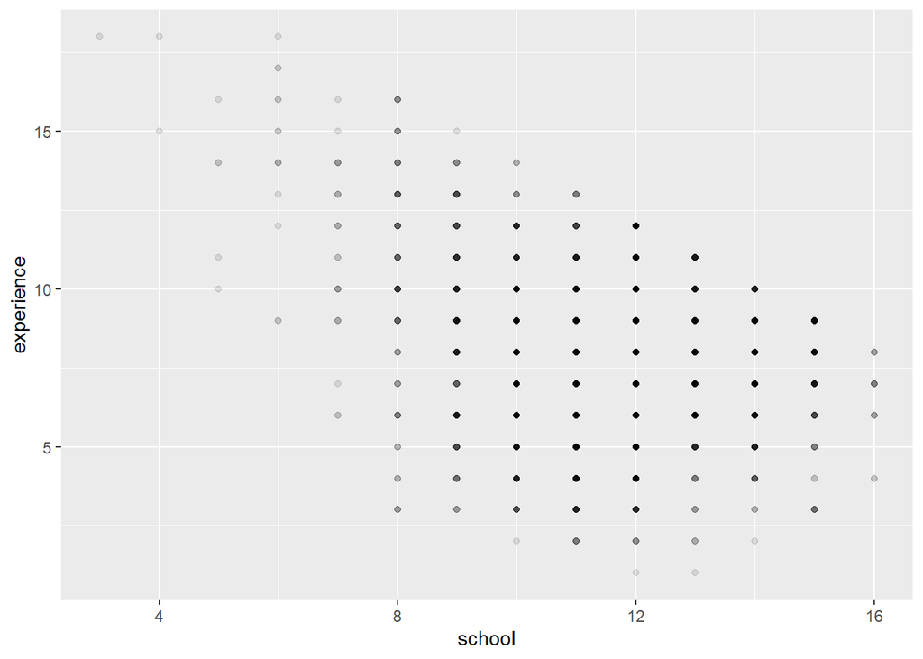

```r
ggplot(wage) +
  geom_point(mapping = aes(school, experience), alpha = 0.1)
```

The years of experience seem to decrease as the years of schooling increases.

### 1.3.2 : There is a negative correlation between years of experience and years of schooling.

Produce a similar plot describing the relationship between years of experience and wage. (1 pt)

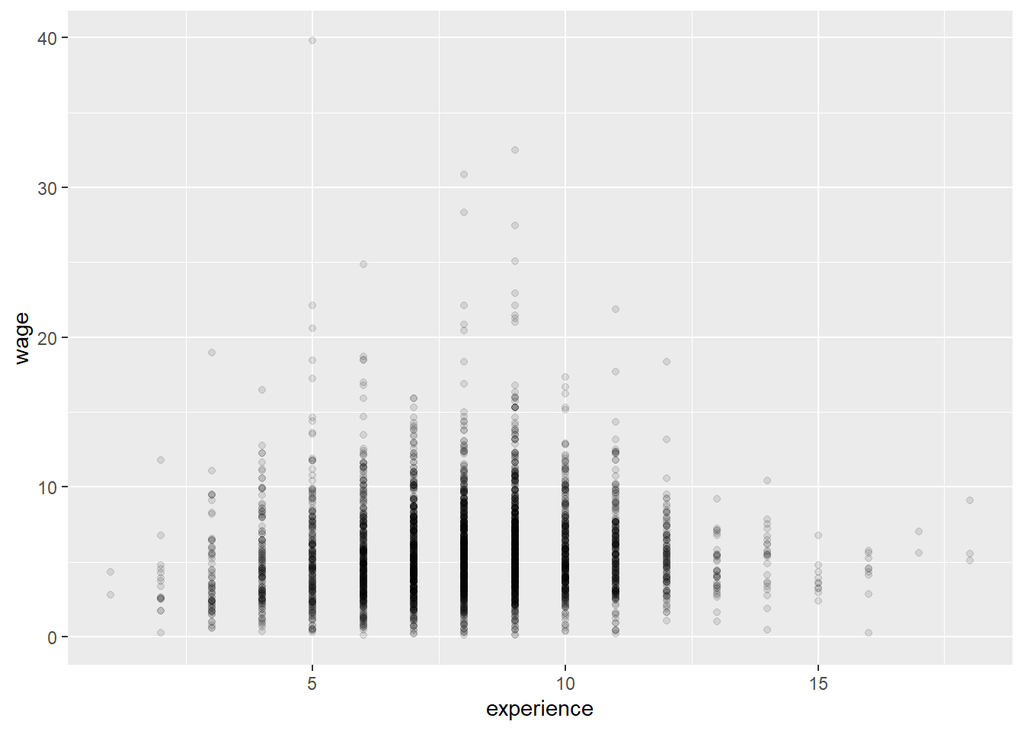

```r
ggplot(wage) +
  geom_point(mapping = aes(experience, wage), alpha = 0.1)
```

### 1.3.3 :

Does the relationship between hourly wage and years of experience differ between the sexes? (1 Points)

Color your previous plot according to the variable `sex` to investigate.

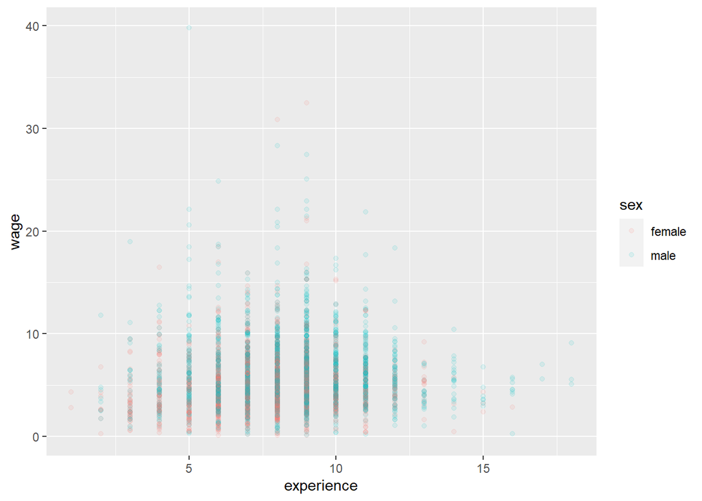

```r
ggplot(wage) +
  geom_point(mapping = aes(experience, wage, color = sex), alpha = 0.1)
```

### 1.3.4 : There is not a definite trend, as the trends of the data are hard to read, but it appears that men tend to have higher wages per each year of experience.

Let’s compute confidence intervals to be more precise. We will spend time explicitly on inference for means later in the semester, but for now, recall that a $100(1-\alpha)\%$ confidence interval for a single mean is given by $\bar{x} \pm t_{\alpha, n-1} \frac{s_x}{n}$. We saw how to use the `group_by` command in one of our student activities within the EDA lecture. I would like you to group the `wages` data by sex, then fill in the blanks to produce approximately 95% confidence intervals for average wage across the two genders. Note: since n is so large here, I will simply use the z distribution as an appropriate approximation of the t. (2 pt)

```r
wage %>%
  group_by(sex) %>%
  summarize(n=n(),mean=mean(wage), se=sd(wage) / sqrt(n),
            lb=mean - 1.96 * se,ub=mean + 1.96 * se)
```

```
## # A tibble: 2 x 6
##   sex        n  mean     se    lb    ub
##   <fct>  <int> <dbl>  <dbl> <dbl> <dbl>
## 1 female  1569  5.15 0.0726  5.00  5.29
## 2 male    1725  6.31 0.0842  6.15  6.48
```

INTERPRETATION: The wages are clearly split by gender, such that men are tending to earn more than women.

### 1.3.5 :

Does the relationship between hourly wage and years of schooling differ between the sexes? (0.5 Points)

Repeat the above interval process replacing `wage` with `school`. Does there seem to be a clear distinction between female and male regarding this relationship?

```r
wage %>%
  group_by(sex) %>%
  summarize(n=n(),mean=mean(school), se=sd(school) / sqrt(n),
            lb=mean - 1.96 * se,ub=mean + 1.96 * se)
```

```
## # A tibble: 2 x 6
##   sex        n  mean     se    lb    ub
##   <fct>  <int> <dbl>  <dbl> <dbl> <dbl>
## 1 female  1569  11.8 0.0389  11.8  11.9
## 2 male    1725  11.4 0.0418  11.4  11.5
```

INTERPRETATION: There is a slight difference between the men and women via schooling, wherein women tend to have slightly more education.

### 1.3.6 :

What is the relationship between hourly wage and the interaction between the years of experience and years of schooling? (0.5 Points)

As years of experience increases relative to years of schooling, wage does not change significantly, however, as schooling increases, wage tends to increase regardless of experience.

The graphic below summarizes the average hourly wage for the different combinations of schooling and experience level. The additional `facet_grid(~sex)` makes comparing the relationship of the three key numeric variables between the sexes quite easy.

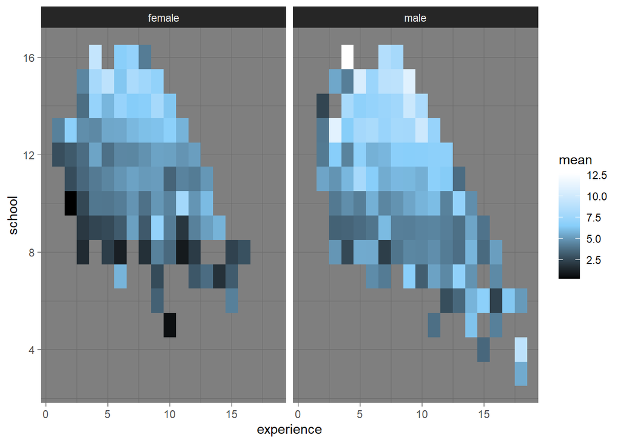

```r
wage %>%
  group_by(experience,school,sex) %>%
  summarize(n=n(),mean=mean(wage)) %>%
  ungroup() %>%
  ggplot() +
    geom_tile(aes(x=experience,y=school,fill=mean)) +
  scale_fill_gradientn(colors=c("black","lightskyblue","white"))+
    facet_grid(~sex) + theme_dark()
```

Question: What are some differences between the sexes regarding this relationship that are apparent in this chart? Write your answer in complete sentences below:

This chart showcases some differences between the sexes, as men tend to have higher wages across the board, but also tend to have fewer years of schooling, at least, on the lower end. Similarly, some men have more years of experience than the women at the highest end of experience.

[^1]: This is probably because the mode has several definitions with varying levels of precision.